# Impact of add-on SDK fix

Updated November 02, 2016

First, load the table of MPC add-ons and identify those most affected by the fix.

```r
addonsDT <- fread("addons-mpc.csv")
## Change "None" to NA.
for(col in names(addonsDT)) {
    addonsDT[get(col) == "None", eval(col) := NA]
}
## Convert boolean columns to logical (loaded as character because of "None"s)
## via numeric (since "TRUE/FALSE" strings were loaded as "1"/"0").
bool_cols <- c("node_modules", "packages", "package_json")
addonsDT[, eval(bool_cols) :=
    lapply(bool_cols, function(col) { as.logical(as.numeric(get(col))) })]
## Add-ons affected by the fix have package_json TRUE and large numbers of
## JS files.
affectedAddonsDT <- addonsDT[package_json == TRUE,
    list(guid = id, users, js_files,
        name = sub("^([^/]*/)+([^-]+)(.*)$", "\\2", download_url))]
save(addonsDT, affectedAddonsDT, file = "addons-tables.RData")
```

Load and format the data. It is split across 3 data tables:

- `main` with one row per session containing scalar measures
- `addons` with one row per add-on per session
- `hangs` with one row per hang time (histogram bin) per session

```r
datadir <- "addon-sdk-fix-data_2016-11-02"
dt_main <- as.data.table(read_feather(file.path(datadir, "main.feather")))
dt_addons <- as.data.table(read_feather(file.path(datadir, "addons.feather")))
dt_hangs <- as.data.table(read_feather(file.path(datadir, "hangs.feather")))

## Reformat some columns for convenience.
dt_main[, build_date := as.Date(substr(build_id, 1, 8), format = "%Y%m%d")]
## Ignore versions for Mac and Linux.
dt_main[sys_os != "Windows_NT", sys_os_version := NA]

## Identify add-ons of interest.

## Categorize add-ons according to the number of JS files:
## 50+ (heavy), 20-50 (medium), all (affected).
affectedAddonsDT[, heavy_js := js_files >= 50][,
    medium_js := js_files >= 20 & js_files < 50][,
    affected := TRUE]
setkey(affectedAddonsDT, guid)
setkey(dt_addons, guid)
dt_addons_cols <- names(dt_addons)
affected_addons_cols <- c("heavy_js", "medium_js", "affected")
dt_addons <- affectedAddonsDT[dt_addons,
    c(dt_addons_cols, affected_addons_cols), with = FALSE]
for(acol in affected_addons_cols)
    dt_addons[is.na(get(acol)), eval(acol) := FALSE]
## Identify VDH 6.1.1 separately.
dt_addons[, is_vdh := (guid == "{b9db16a4-6edc-47ec-a1f4-b86292ed211d}" &
    substr(version, 1, 5) == "6.1.1")]

## Summarize each sessions add-ons according to whether they had affected
## add-ons.
session_addons <- dt_addons[, list(has_vdh = any(is_vdh),
    num_addons_affected = sum(affected),
    num_addons_medium_js = sum(medium_js),
    num_addons_heavy_js = sum(heavy_js)),
    keyby = session_id]
setkey(dt_main, session_id)
dt_main <- session_addons[dt_main]
dt_main[is.na(has_vdh), has_vdh := FALSE]
for(acol in grep("^num_addons", names(session_addons), value = TRUE))
    dt_main[is.na(get(acol)), eval(acol) := 0]

rm(dt_addons_cols)
save(list = ls(pattern = "^dt_"), file = "addon-sdk-working-data.RData")
```

```r
load("addons-tables.RData")
load("addon-sdk-working-data.RData")
```

Focus first on “good” profiles, that were active both before and after the change, and had a constant e10s setting and list of active add-ons (ignoring add-on versions) throughout.

```r
dt_good <- dt_main[both_periods & constant_e10s & constant_addons_guid]
nprof_good <- dt_good[, length(unique(client_id))]
```

How many sessions have e10s enabled, and have add-ons?

```r
dt_good[, list(n_sessions = .N), by = list(e10s, has_addons = num_addons_nonsys > 0)][
    order(e10s, has_addons, decreasing = TRUE)][,
    pct_sessions := pctLabelText(n_sessions / nrow(dt_good))][,
    n_sessions := bigNum(n_sessions)][]
```

```
##     e10s has_addons n_sessions pct_sessions
## 1:  TRUE       TRUE    264,529        87.2%
## 2:  TRUE      FALSE     14,801         4.9%
## 3: FALSE       TRUE     23,545         7.8%
## 4: FALSE      FALSE        368         0.1%
```

For those sessions that have add-ons, how many have add-ons most affected by the changes, and specifically VDH?

```r
dt_good[num_addons_nonsys > 0, list(n_sessions = .N),
    by = list(has_addons_affected = num_addons_affected > 0, has_addons_medium_js = num_addons_medium_js > 0,
        has_addons_heavy_js = num_addons_heavy_js > 0, has_vdh)][
    order(has_addons_affected, has_addons_medium_js, has_addons_heavy_js, has_vdh)][,
    pct_sessions := pctLabelText(n_sessions / nrow(dt_good))][,
    n_sessions := bigNum(n_sessions)][]
```

```
##    has_addons_affected has_addons_medium_js has_addons_heavy_js has_vdh
## 1:               FALSE                FALSE               FALSE   FALSE
## 2:                TRUE                FALSE               FALSE   FALSE
## 3:                TRUE                FALSE                TRUE   FALSE
## 4:                TRUE                FALSE                TRUE    TRUE
## 5:                TRUE                 TRUE               FALSE   FALSE
## 6:                TRUE                 TRUE                TRUE   FALSE
## 7:                TRUE                 TRUE                TRUE    TRUE
##    n_sessions pct_sessions
## 1:    215,232        71.0%
## 2:     38,676        12.8%
## 3:      7,017         2.3%
## 4:     19,207         6.3%
## 5:      6,597         2.2%
## 6:        428         0.1%
## 7:        917         0.3%
```

Compare the hang stats before and after for each profile. Summarize a session’s hang times by the mean of log times reported during that session. Count a session with no hangs as 0.

```r
dt_hangs_mean <- dt_hangs[, list(hang_time = wtd.mean(log(hang_time + 1, 2), count)), keyby = session_id]
setkey(dt_good, session_id)
dt_good <- dt_hangs_mean[dt_good]
dt_good[is.na(hang_time), hang_time := 0]
## Drop sessions with interrupted startup.
dt_good <- dt_good[was_startup_interrupted == FALSE]
## Order the period labels for display.
dt_good[, period := factor(period, levels = c("before", "after"))]
## Add indicators for add-ons.
dt_good[, has_addons := factor(ifelse(num_addons_nonsys > 0, "has addons", "no addons"), levels = c("has addons", "no addons"))]#[,
#    has_addons_affected := num_addons_affected > 0][,
#    has_addons_medium_js := num_addons_medium_js > 0][,
#    has_addons_heavy_js := num_addons_heavy_js > 0]
dt_good[, e10s_state := factor(ifelse(e10s, "e10s on", "e10s off"), levels = c("e10s on", "e10s off"))]
```

Are there differences in per-session hang times? Separate sessions with hangs from those without.

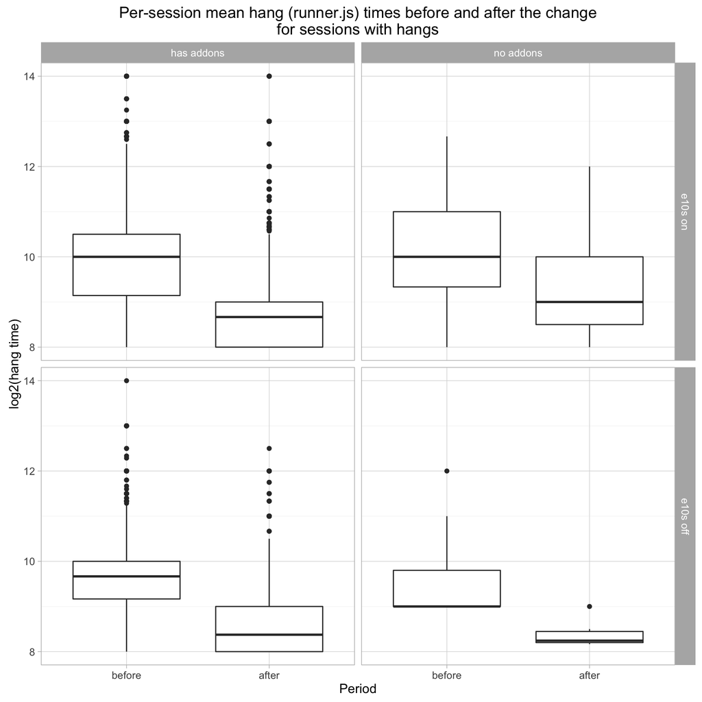

```r
## Boxplots of hang times for sessions with hangs.
ggplot(dt_good[has_hangs == TRUE], aes(period, hang_time)) +
    geom_boxplot() +
    ## Expand over range of possible hang times.
    #expand_limits(y = dt_hangs[, range(log(hang_time + 1, 2)) + c(-1, 1)]) +
    facet_grid(e10s_state ~ has_addons) +
    labs(title = "Per-session mean hang (runner.js) times before and after the change\nfor sessions with hangs",
        x = "Period",
        y = "log2(hang time)")
```

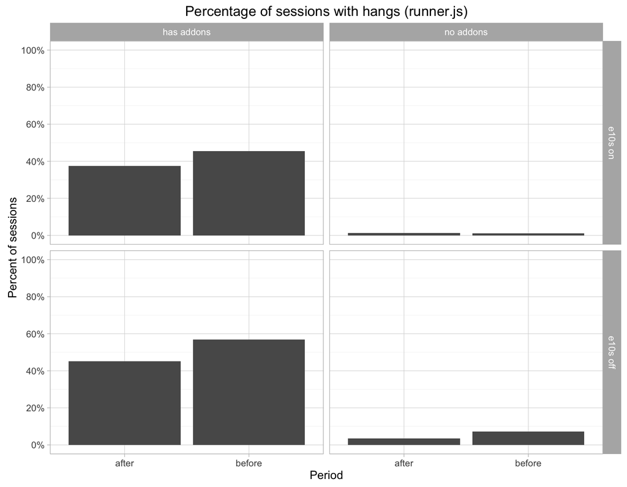

```r
## Proportions of sessions without hangs.
ggplot(dt_good[, list(prop_hangs = mean(has_hangs)), by = list(e10s_state, has_addons, period)],
        aes(factor(period, levels = rev(levels(period))), prop_hangs)) +
    geom_bar(stat = "identity") + #coord_flip() +
    facet_grid(e10s_state ~ has_addons) +
    scale_y_continuous(breaks = interval.breaks(0.2), labels = pct.labels,
        limits = c(0,1)) +
    labs(title = "Percentage of sessions with hangs (runner.js)",
        x = "Period",
        y = "Percent of sessions")
```

Look into the per-client before/after differences.

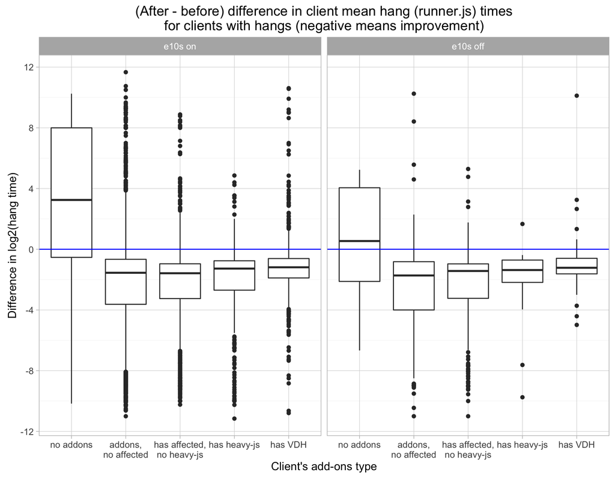

```r
## Many columns should have the same value across all sessions for a given client.
per_client_cols <- c("e10s", "e10s_state", "num_addons_nonsys", "num_addons_affected",
    "num_addons_medium_js", "num_addons_heavy_js", "has_vdh",
    grep("^sys", names(dt_good), value = TRUE))
dt_good_prof <- dt_good[, c(list(hang_time = mean(hang_time[period == "after"]) - mean(hang_time[period == "before"]),
    has_hangs = any(has_hangs)),
    setNames(lapply(per_client_cols, function(ccol) { get(ccol)[1] }), per_client_cols)),
    by = client_id]

## Make boxplots of differences according to add-on types and e10s status, for profiles that had hangs.
dt_good_prof[, addon_type := factor(ifelse(num_addons_nonsys == 0, "no addons",
    ifelse(num_addons_affected == 0, "addons,\nno affected",
    ifelse(num_addons_heavy_js == 0, "has affected,\nno heavy-js",
    ifelse(!has_vdh, "has heavy-js", "has VDH")))),
    levels = c("no addons", "addons,\nno affected", "has affected,\nno heavy-js",
        "has heavy-js", "has VDH"))]

plot_diff_addon <- function() {
    ggplot(dt_good_prof[has_hangs == TRUE], aes(addon_type, hang_time)) +
        geom_boxplot() +
        geom_hline(yintercept = 0, size = 0.5, colour = "blue") +
        scale_y_continuous(breaks = interval.breaks(4)) +
        labs(title = "(After - before) difference in client mean hang (runner.js) times\nfor clients with hangs (negative means improvement)",
            x = "Client's add-ons type",
            y = "Difference in log2(hang time)")
}
plot_diff_addon() + facet_wrap(~e10s_state)
```

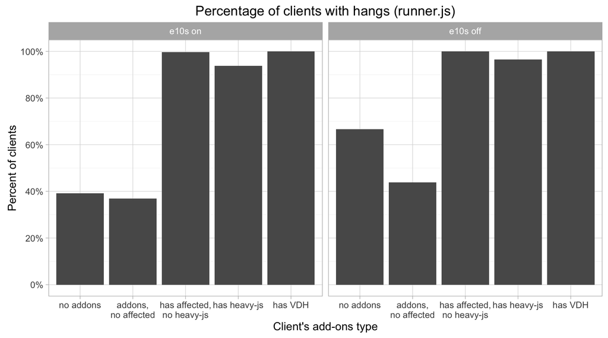

```r
## Also plot the corresponding proportions of clients with hangs.
dt_good_prop_hangs <- dt_good_prof[, list(has_hangs = mean(has_hangs)),
    by = list(e10s_state, addon_type)]
plot_prop_addon <- function() {
    ggplot(dt_good_prop_hangs, aes(addon_type, has_hangs)) +
        geom_bar(stat = "identity") +
        scale_y_continuous(breaks = interval.breaks(0.2), labels = pct.labels,
            limits = c(0,1)) +
        labs(title = "Percentage of clients with hangs (runner.js)",
            x = "Client's add-ons type",
            y = "Percent of clients")
}
plot_prop_addon() + facet_wrap(~e10s_state)
```

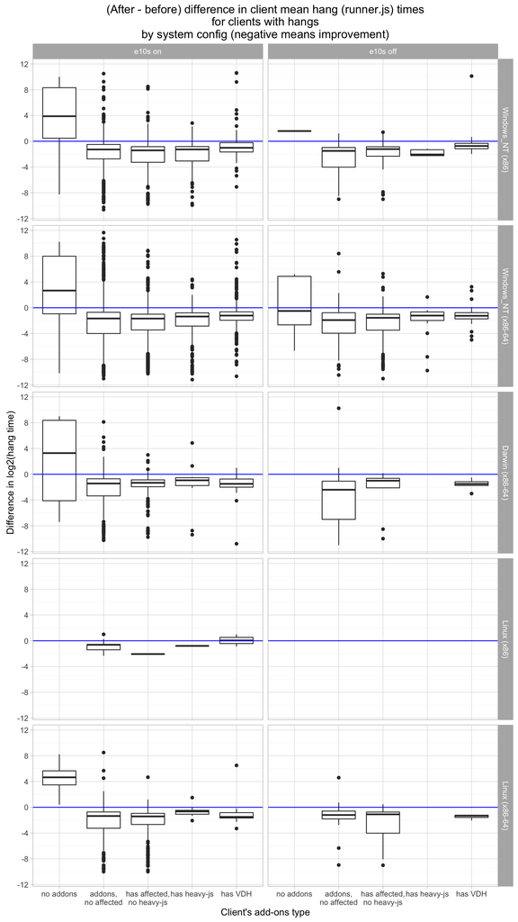

```r
## Same but split out by system config.
dt_good_prof[, sys_os := factor(sys_os, levels = c("Windows_NT", "Darwin", "Linux"))][,
    sys_arch := factor(sys_arch, levels = c("x86", "x86-64"))]
sys_arch_label <- function(os, arch) { sprintf("%s (%s)", os, arch) }
sys_arch_levels <- dt_good_prof[, .N, by = list(sys_os, sys_arch)][order(sys_os, sys_arch)][,
    sys_arch_label(sys_os, sys_arch)]
dt_good_prof[, sys_os_arch := factor(sys_arch_label(sys_os, sys_arch), levels = sys_arch_levels)]

plot_diff_addon() + facet_grid(sys_os_arch ~ e10s_state) +
    ggtitle("(After - before) difference in client mean hang (runner.js) times\nfor clients with hangs\nby system config (negative means improvement)")
```

```r
dt_good_prop_hangs <- dt_good_prof[, list(has_hangs = mean(has_hangs)),
    by = list(e10s_state, addon_type, sys_os_arch)]
plot_prop_addon() + facet_grid(sys_os_arch ~ e10s_state) +
    ggtitle("Percentage of clients with hangs (runner.js)\nby system config")
```

[output not shown]